# Homework 2 Report

## Name

Madison Rudkin - mgr2885

### Setup

Read in the data with `read_csv()` and store the data as an R object named `dataset`. Check the data to make sure all of the expected observations and variables are there.

```r
## Load the data and any necessary packages here.
library(readr)
library(dplyr)
library(ggplot2)

## Read dataset
dataset <- read_csv("maacs.csv.gz")

## Inspect structure
head(dataset)
```

```
## # A tibble: 6 × 10
##   id         age gender  fev1   eNO cough_days  pm25   no2 mouse mouse_allergic
##   <chr>    <dbl> <chr>  <dbl> <dbl>      <dbl> <dbl> <dbl> <dbl> <chr>
## 1 fd171e2d  14.7 male    1.78   141          2  15.6  NA    2423 yes
## 2 a66fc33a  13.6 female  2.12    68          8  18.9  12.8   939 yes
## 3 fc038e68  14.5 male    2.73   210          2  17.8  NA     200 no
## 4 8e28b8c2  14.0 female  2.36    23          0  14.0  NA      NA no
## 5 b2699b54  16.6 female  3.13    18         14  17.9  31.0 10371 no
## 6 7d4f3508  16.6 female  2.59   128          0  43.8  10.6  4789 yes
```

```r
summary(select(dataset, age, fev1))
```

```
##       age              fev1
##  Min.   : 5.000   Min.   :0.650
##  1st Qu.: 7.713   1st Qu.:1.370
##  Median :10.915   Median :1.870
##  Mean   :11.215   Mean   :1.994
##  3rd Qu.:14.758   3rd Qu.:2.490
##  Max.   :17.890   Max.   :5.000
##                   NA's   :17
```

## Part 1

We will first consider the relationship between FEV1 and age. In general, it is expected that as children get older (and hence, larger in size), their FEV1 values should get higher.

Consider the statement “FEV1 values in children are higher in older children relative to younger children”.

Write a function in R that takes the `dataset` object as an argument and returns `TRUE` if the statement above is true for the dataset and `FALSE` otherwise.

NOTE: In order to write this function, you will need to translate the statement above into something that can be checked with the data. There are many ways in which you can do that translation correctly and you only need to pick one way here.

NOTE: For this part, do not use any plots.

```r
# Check if older kids have higher FEV1 than younger kids
check_fev1_age <- function(data) {

  # Keep only age and fev1, drop missing values
  df <- data %>% select(age, fev1) %>% na.omit()

  # Find cutoffs for youngest and oldest thirds
  qs <- quantile(df$age, probs = c(1/3, 2/3))

  # Split into younger and older groups
  younger <- df %>% filter(age <= qs[1])
  older   <- df %>% filter(age >= qs[2])

  # Return TRUE if older mean FEV1 > younger mean FEV1
  mean(older$fev1) > mean(younger$fev1)
}

# Run the function
check_fev1_age(dataset)
```

```
## [1] TRUE
```

## Part 2

Fit a linear regression model with FEV1 as the outcome and age as a predictor.

How much does FEV1 change for a 1-year increase in the child’s age?

```r
## Add your code here
# Fit linear regression of FEV1 on age
model <- lm(fev1 ~ age, data = dataset)

summary(model)
```

```
##
## Call:
## lm(formula = fev1 ~ age, data = dataset)
##
## Residuals:
##      Min       1Q   Median       3Q      Max
## -1.51099 -0.27100  0.00196  0.23616  2.15477
##
## Coefficients:
##              Estimate Std. Error t value Pr(>|t|)
## (Intercept) -0.001199   0.134696  -0.009    0.993
## age          0.171162   0.010984  15.583   <2e-16 ***
## ---
## Signif. codes:  0 '***' 0.001 '**' 0.01 '*' 0.05 '.' 0.1 ' ' 1
##
## Residual standard error: 0.4827 on 131 degrees of freedom
##   (17 observations deleted due to missingness)
## Multiple R-squared:  0.6496, Adjusted R-squared:  0.6469
## F-statistic: 242.8 on 1 and 131 DF,  p-value: < 2.2e-16
```

```r
# Get slope (effect of age)
coef(model)["age"]
```

```
##       age
## 0.1711623
```

```r
# Get 95% CI for slope
confint(model)["age", ]
```

```
##     2.5 %    97.5 %
## 0.1494341 0.1928904
```

Write your data analysis statement interpreting the regression model here:

In the linear regression of FEV1 on age, the estimated slope for age is 0.171. This means that, on average, a child’s FEV1 increases by about 0.17 liters for every additional year of age. The 95% confidence interval for this slope is (0.149, 0.193), which does not include zero. The associated p-value is < 2e-16, providing very strong evidence that the relationship between age and FEV1 is not due to chance. The model explains approximately 65% of the variability in FEV1 (R² = 0.65), which indicates a strong positive association.

## Part 3

Develop **three** supporting premises derived from the data that support the statement you wrote in Part 2. These can be plots, other summary statistics, or model results.

NOTE:

- At least one supporting premise should use a plot.
- Do not use the code you write in Part 1 as a supporting premise

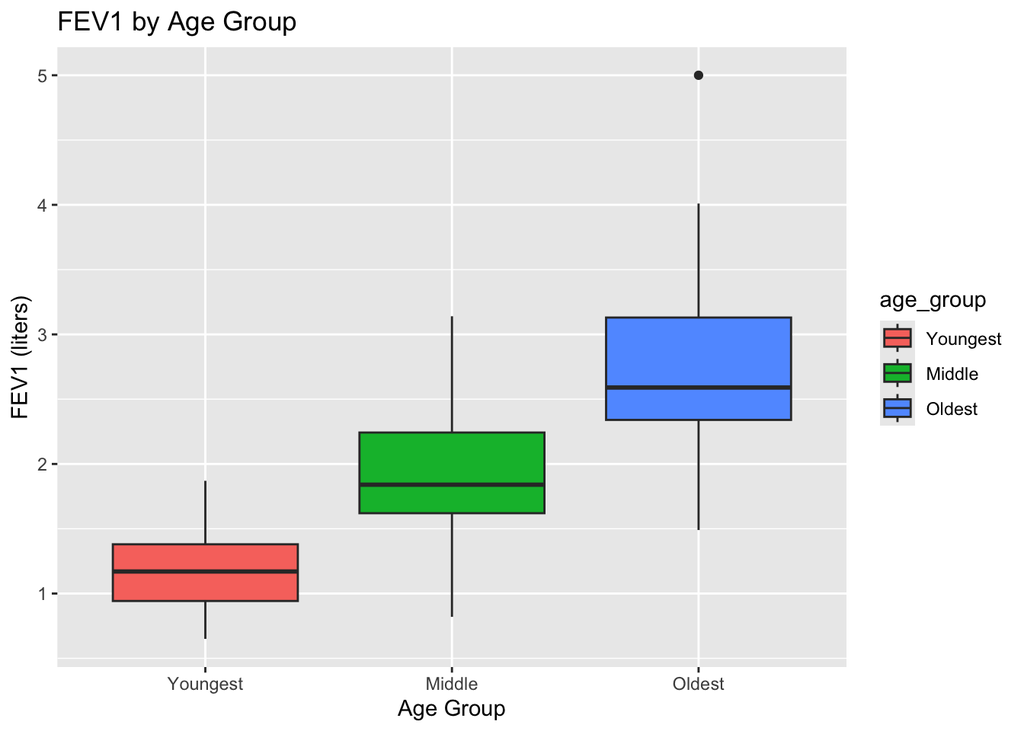

```r
## Add your code here

# Get cutoffs for youngest, middle, and oldest thirds of age
qs <- quantile(dataset$age, probs = c(1/3, 2/3))

# Add a new column for age group based on cutoffs
dataset <- dataset %>%
  mutate(age_group = cut(age,
                         breaks = c(-Inf, qs[1], qs[2], Inf),
                         labels = c("Youngest", "Middle", "Oldest")))

# Boxplot of FEV1 by age group
ggplot(dataset, aes(x = age_group, y = fev1, fill = age_group)) +
  geom_boxplot() +
  labs(title = "FEV1 by Age Group",
       x = "Age Group", y = "FEV1 (liters)")
```

Write the three supporting premise statements here:

1. The boxplot of FEV1 by age group shows that the median FEV1 increases across groups from youngest to oldest. The youngest children have the lowest values, while the oldest children have the highest values. This supports the statement that older children have higher FEV1 than younger children.
2. The linear regression model has an R² of approximately 0.65. This means that about 65% of the variability in FEV1 is explained by age alone, which is a strong amount of explanatory power for a single predictor.
3. The regression slope for age is estimated at 0.171, with a 95% confidence interval of (0.149, 0.193). Since the interval does not include zero, this provides strong evidence that the relationship between age and FEV1 is positive.

## Part 4

For each of the supporting premises above, write a function that takes the `dataset` object as an argument and returns `TRUE` if the supporting premise statement above is true for the dataset and `FALSE` otherwise.

For statements involving plots, instead of returning `TRUE` or `FALSE`, you function should do two things:

1. Produce the plot that is used in the statement
2. Produce a hypothetical version of the plot in the event that the statement is true. This can be done using simulated data or by simply hand drawing a plot.

```r
premise1_boxplot <- function(data) {
  # Split ages into thirds
  qs <- quantile(data$age, probs = c(1/3, 2/3))
  data$age_group <- cut(data$age,
                        breaks = c(-Inf, qs[1], qs[2], Inf),
                        labels = c("Youngest", "Middle", "Oldest"))

  # Actual boxplot
  p_actual <- ggplot(data, aes(x = age_group, y = fev1, fill = age_group)) +
    geom_boxplot() +
    labs(title = "FEV1 by Age Group (Actual Data)",
         x = "Age Group", y = "FEV1 (liters)")
  print(p_actual)

  # Hypothetical version via simulating clear increasing pattern
  set.seed(67)
  sim_data <- data.frame(
    age_group = rep(c("Youngest", "Middle", "Oldest"), each = 50),
    fev1 = c(rnorm(50, mean = 1.5, sd = 0.2),   # younger = lower
             rnorm(50, mean = 2.5, sd = 0.2),   # middle = medium
             rnorm(50, mean = 3.5, sd = 0.2))   # oldest = higher
  )

  p_hypo <- ggplot(sim_data, aes(x = age_group, y = fev1, fill = age_group)) +
    geom_boxplot() +
    labs(title = "FEV1 by Age Group (Hypothetical True Pattern)",
         x = "Age Group", y = "FEV1 (liters)")
  print(p_hypo)
}
```

```r
premise2_r2 <- function(data, threshold = 0.5) {
  # Fit linear regression of FEV1 on age
  fit <- lm(fev1 ~ age, data = data)

  # Get R-squared value
  r2 <- summary(fit)$r.squared

  # Return TRUE if R² is greater than threshold (default is 0.5)
  r2 > threshold
}
```

```r
premise3_slope <- function(data) {
  # Fit linear regression of FEV1 on age
  fit <- lm(fev1 ~ age, data = data)

  # Extract slope for age
  slope <- coef(fit)["age"]

  # Get 95% confidence interval for slope
  ci <- confint(fit)["age", ]

  # Return TRUE if slope > 0 and CI excludes 0
  (slope > 0) & (ci[1] > 0)
}
```

Execute each of your function and show that the produce the expected output.

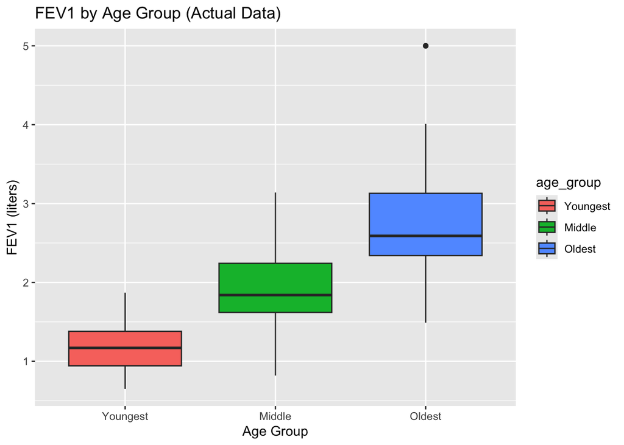

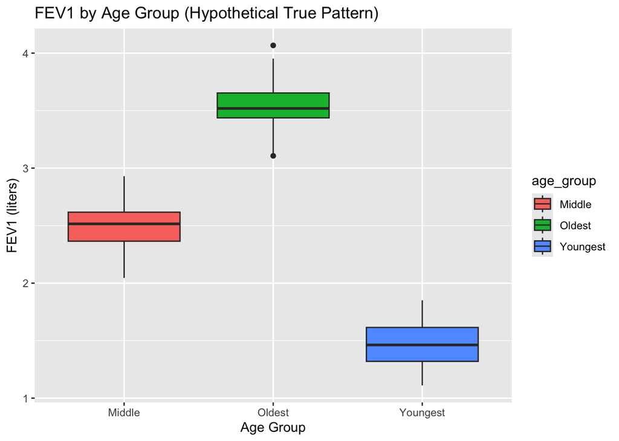

```r
premise1_boxplot(dataset)
```

```r
premise2_r2(dataset)
```

```
## [1] TRUE
```

```r
premise3_slope(dataset)
```

```
##  age
## TRUE
```

## Part 5

Describe one alternative to the primary statement “FEV1 values in children are higher in older children relative to younger children”.

An alternative to the primary statement “FEV1 values in children are higher in older children relative to younger children” is “FEV1 increases with body size (such as height or weight), not directly with age. The observed association between age and FEV1 is due to confounding.”

Create a fault tree for the alternative outcome describing how the alternative outcome could be realized in the data even if the primary statement were true.

Your fault tree should be created as a separate image and does not need to be created in R. Upload the image of the fault tree to Canvas.